# JuliaとQuartoを使ってレポートを書く 2

## if文

`if`/`elseif`/`else`/`end`

の四つの要素に分かれます。

```
if 条件1
  戻り値
elseif 条件2
  戻り値
else if 条件3
  戻り値
...
else #それ以外
  戻り値
end #endで必ず閉じる
```

```julia
Num = 2.5
```

```julia
if Num > 3
    "big"
elseif 1 ≤ Num ≤ 3
    "medium"
else
    "small"
end
```

```
"medium"
```

## while文

while文を使って「条件が満たされている間だけ」ループを続けるように計算させることができます。

```julia
function solve_cos_fixedpoint()
    x    = 1.0
    tol  = 1e-6
    diff = 1.0

    while diff > tol
        x_new = cos(x)
        diff  = abs(x_new - x)
        x     = x_new
    end
    return x
end

fixpoint = solve_cos_fixedpoint()
```

```julia
println("収束解 = $fixpoint")
```

```
収束解 = 0.7390855263619245
```

iterationなど、ある判定基準のところで計算を打ち切る場合に有用です。

## ネスト（入れ子）と内包表記

for文と同じことを内包表記を使うと1行で書くことができます。

```julia
# for文と同じことを内包表記で
pairs = [(i,j) for i in 1:3 for j in 1:2]
```

```julia
println(pairs)
```

```
[(1, 1), (1, 2), (2, 1), (2, 2), (3, 1), (3, 2)]
```

内包表記の基本構文は `[変数 for 変数 in 繰り返すインデックスの範囲]` です。

繰り返すインデックスの範囲は、if文で条件をつけることができます。

```julia
# iが奇数、jが偶数のペアが返ってくるように条件を指定する
pairs2 = [(i,j) for i in 1:3 if i % 2 != 0 for j in 1:3 if j % 2 == 0]
```

```julia
println(pairs2)
```

```
[(1, 2), (3, 2)]
```

## パッケージの使い方

### パッケージのインストール

標準機能だけでは足りないときには外部ライブラリを利用することになります。

流れ:

1. `Pkg.add("PackageName")` でインストール
2. `using PackageName` で読み込み
3. 実際に関数を使う

```julia
using Pkg
Pkg.add("Plots")
using Plots
```

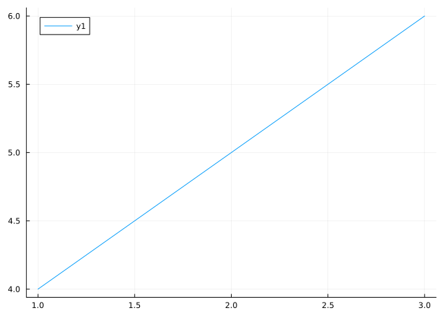

```julia
plot([1,2,3], [4,5,6])
```

ターミナルで`using Pkg; Pkg.add("PackageName")`を実行してパッケージをインストールすることもできます。

```
using パッケージの名前
Pkg.add("パッケージの名前")
```

はいったんやればその後は

```
using パッケージの名前
```

だけでパッケージを使うことが可能です。

### CSVからデータを読みこんでDataFrameで操作する

Juliaでは `CSV.jl` と `DataFrames.jl` を組み合わせて使うことでデータを操作します。

```julia
using Pkg
Pkg.add("CSV")
Pkg.add("DataFrames")
using CSV, DataFrames
```

詳しくは[*DataFrames.jl*の公式サイト](https://dataframes.juliadata.org/stable/)や[Juliaで遊んでみた - データフレーム操作編](https://qiita.com/HiroyukiTachikawa/items/e01917ade931031ec6a1)を参照。

### CSVからデータを読みこむ

**データの読み込み**

`df = CSV.read("dataname.csv", DataFrame)`

```julia
df = CSV.read("sample_dataset.csv", DataFrame)
```

```julia
first(df, 5)   # 先頭5行を表示
```

5×6 DataFrame

| Row | ID Int64 | Name DataStri… | Age Int64 | Department DataStri… | Salary Int64 | YearsExperience Int64 |
| --- | --- | --- | --- | --- | --- | --- |
| 1 | 1 | Alice | 23 | Sales | 40000 | 1 |
| 2 | 2 | Bob | 35 | HR | 50000 | 7 |
| 3 | 3 | Charlie | 45 | IT | 60000 | 15 |
| 4 | 4 | David | 29 | Finance | 55000 | 5 |
| 5 | 5 | Eve | 31 | Sales | 45000 | 6 |

### DataFrameの基本操作

**行・列参照**

```julia
df.Name                  # Name列をSeriesとして取り出す
```

```
20-element DataStrings.StringVector{DataStrings.DataString}:
 "Alice"
 "Bob"
 "Charlie"
 "David"
 "Eve"
 "Frank"
 "Grace"
 "Hank"
 "Ivy"
 "Jack"
 "Kathy"
 "Leo"
 "Mona"
 "Nina"
 "Oscar"
 "Paul"
 "Queen"
 "Rita"
 "Steve"
 "Tina"
```

```julia
df[:, :Salary]            # 列を配列として取り出す
```

```
20-element Vector{Int64}:
 40000
 50000
 60000
 55000
 45000
 62000
 52000
 48000
 47000
 58000
 53000
 61000
 49000
 57000
 54000
 46000
 51000
 56000
 63000
 44000
```

```julia
df[1:10, [:Name, :Salary]]  # 部分選択
```

10×2 DataFrame

| Row | Name DataStri… | Salary Int64 |
| --- | --- | --- |
| 1 | Alice | 40000 |
| 2 | Bob | 50000 |
| 3 | Charlie | 60000 |
| 4 | David | 55000 |
| 5 | Eve | 45000 |
| 6 | Frank | 62000 |
| 7 | Grace | 52000 |
| 8 | Hank | 48000 |
| 9 | Ivy | 47000 |
| 10 | Jack | 58000 |

### データをプロットする

`Plots`パッケージのインストール

```julia
using Pkg
Pkg.add("Plots")
using Plots
```

プロットの基本

- `plot(x, y; オプション...)`
- `x`: 横軸のデータ（ベクトルや配列）
- `y`: 縦軸のデータ（同じ長さのベクトルや配列）
- `; オプション...` : タイトル、軸ラベル、色、凡例など

代表的なプロット関数

| 関数 | 説明 |
| --- | --- |
| `plot(x, y)` | 折れ線グラフ |
| `scatter(x, y)` | 散布図 |
| `bar(x, y)` | 棒グラフ |
| `histogram(x)` | ヒストグラム |

よく使うオプション

- `title = "タイトル"`, `xlabel = "X軸ラベル"`, `ylabel = "Y軸ラベル"`
- `legend = true` **凡例表示**
- `color = :blue` **線や点の色**
- `lw = 2` **線の太さ (line width)**
- `marker = :circle` **散布図の点の形**

など。`Plots.jl` はキーワード引数でカスタマイズできるのが特徴。

プロットの保存

- PNG形式で保存 `savefig("plot.png")`
- PDF形式で保存 `savefig("plot.pdf")`
- SVG形式で保存（ベクター画像） `savefig("plot.svg")`

詳しくは、[Plots.jlのサイトを参照](https://docs.juliaplots.org/stable/)

### データをプロットする

**棒グラフのプロット**

```julia
avg_salary = combine(groupby(df, :Department), :Salary => mean => :AvgSalary) # 部署ごとの平均給与データを作成
```

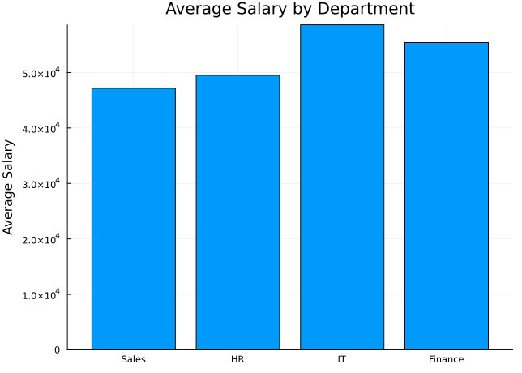

```julia
bar(avg_salary.Department, avg_salary.AvgSalary,
    title = "Average Salary by Department",
    xlabel = "", ylabel = "Average Salary",
    legend = false)
#savefig("plot_avg_salary_Department.pdf")
```

**ヒストグラムのプロット**

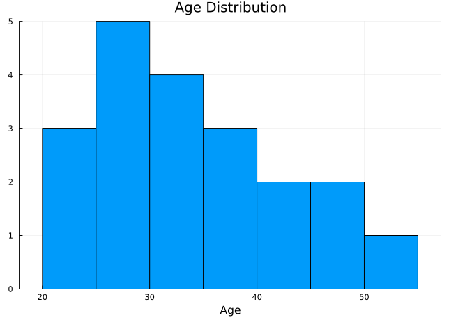

```julia
histogram(df.Age, bins=6,
    title = "Age Distribution",
    xlabel = "Age", ylabel = "", legend = false)
#savefig("plot_Age_Distribution.pdf")
```

**散布図のプロット**

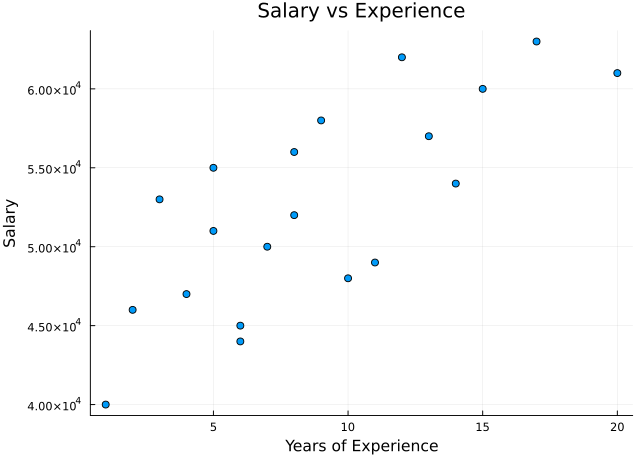

```julia
scatter(df.YearsExperience, df.Salary,
    title = "Salary vs Experience",
    xlabel = "Years of Experience", ylabel = "Salary", legend = false)
#savefig("plot_Salary_vs_Experience.pdf")
```

**複数の図を並べる**

```julia
p1 = scatter(df.YearsExperience, df.Salary,
    title = "Salary vs Experience",
    xlabel = "Years of Experience", ylabel = "Salary", legend = false)

p2 = bar(avg_salary.Department, avg_salary.AvgSalary,
    title = "Average Salary by Department", legend = false)

p3 = histogram(df.Age, bins = 6,
    title = "Age Distribution", xlabel = "Age", ylabel = "", legend = false)
```

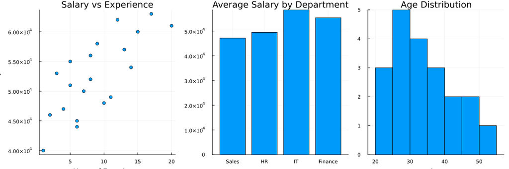

```julia
# 3つの図を並べて表示
plot(p1, p2, p3, layout = (1, 3), size=(1200, 400))
```

### 表を作る

`SummaryTables` パッケージを使うことで表を作ることができます。

インストールと読み込み

```julia
using Pkg
Pkg.add("SummaryTables")

using SummaryTables
```

### 表を作る

簡単な表`simple_table()`

```julia
simple_table(df)
```

| ID | Name | Age | Department | Salary | YearsExperience |
| --- | --- | --- | --- | --- | --- |
| 1 | Alice | 23 | Sales | 40000 | 1 |
| 2 | Bob | 35 | HR | 50000 | 7 |
| 3 | Charlie | 45 | IT | 60000 | 15 |
| 4 | David | 29 | Finance | 55000 | 5 |
| 5 | Eve | 31 | Sales | 45000 | 6 |
| 6 | Frank | 40 | IT | 62000 | 12 |
| 7 | Grace | 22 | Finance | 52000 | 8 |
| 8 | Hank | 34 | HR | 48000 | 10 |
| 9 | Ivy | 28 | Sales | 47000 | 4 |
| 10 | Jack | 30 | IT | 58000 | 9 |
| 11 | Kathy | 27 | Finance | 53000 | 3 |
| 12 | Leo | 50 | Sales | 61000 | 20 |
| 13 | Mona | 41 | HR | 49000 | 11 |
| 14 | Nina | 36 | IT | 57000 | 13 |
| 15 | Oscar | 33 | Finance | 54000 | 14 |
| 16 | Paul | 26 | Sales | 46000 | 2 |
| 17 | Queen | 24 | HR | 51000 | 5 |
| 18 | Rita | 39 | IT | 56000 | 8 |
| 19 | Steve | 48 | Finance | 63000 | 17 |
| 20 | Tina | 29 | Sales | 44000 | 6 |

# 第1回 & 第2回 TAセッションでやったこと

第2回TAセッションではQuartoとJuliaの基礎知識を学びました。これで課題を作成する基礎の部分は身につけられたと思います。

## 終わりに

- 質問があればお気軽に。TAセッションでもメールでもbeef+でもなんでも。